# Syntax basic R

Idrissa Dabo

2022-05-28

## Important Keboard shorcut

to see all shortcut you can click to tools, keyboard shortcut help or directly click in console or in the script click **Alt + shift + k**.

Some useful shortcut that i usually use to organize my syntax:

- To comment or uncomment **ctrl + shift +c**
- To Run selected lines **ctrl+ enter**
- To create a section **ctrl+shift+R**
- To Run a section **ctrl+alt+T**
- Delete line **ctrl+D**

In R we have 4 basics functions important to create function Collect **c()**, repeat **rep()**, sequence1 **:**, sequence2 **seq()** to create objects click to **Alt+6** or **Alt+ -**. For example in the code below we gonna create tree variables or Objects a, b and d

```r
a <- 6
b <- 10
d <- a+b
```

For numerical object you can directly click the value like in the code above but for String or character you need to put the element between **quote ” “**. Example below:

```r
names <- "Prince"
Country <-  "Ghana"
```

## Vectors

1. Collect and repeat In R vectors can be consider as column in excel. For example if i want to create a column names like in excel with elements *Idrissa, Prince and Jacob* i can use the function collect *c()*

```r
names <- c("Idrissa", "prince", "Jacob")
age <- c(30,29,25)
Country <- c("Senegal", "Ghana", "Mali")
```

Each element of the code above can be consider as a column. On the other hand how can i do if i want to **repeat** the names of **Prince 100 times** do i need to repeat prince 100 times in the collect c() function. Yes i can but it will take a lot of times so i can use the function **rep()** to do it quickly

```r
rep("Prince", 100)
```

```
##   [1] "Prince" "Prince" "Prince" "Prince" "Prince" "Prince" "Prince" "Prince"
##   [9] "Prince" "Prince" "Prince" "Prince" "Prince" "Prince" "Prince" "Prince"
##  [17] "Prince" "Prince" "Prince" "Prince" "Prince" "Prince" "Prince" "Prince"
##  [25] "Prince" "Prince" "Prince" "Prince" "Prince" "Prince" "Prince" "Prince"
##  [33] "Prince" "Prince" "Prince" "Prince" "Prince" "Prince" "Prince" "Prince"
##  [41] "Prince" "Prince" "Prince" "Prince" "Prince" "Prince" "Prince" "Prince"
##  [49] "Prince" "Prince" "Prince" "Prince" "Prince" "Prince" "Prince" "Prince"
##  [57] "Prince" "Prince" "Prince" "Prince" "Prince" "Prince" "Prince" "Prince"
##  [65] "Prince" "Prince" "Prince" "Prince" "Prince" "Prince" "Prince" "Prince"
##  [73] "Prince" "Prince" "Prince" "Prince" "Prince" "Prince" "Prince" "Prince"
##  [81] "Prince" "Prince" "Prince" "Prince" "Prince" "Prince" "Prince" "Prince"
##  [89] "Prince" "Prince" "Prince" "Prince" "Prince" "Prince" "Prince" "Prince"
##  [97] "Prince" "Prince" "Prince" "Prince"
```

```r
rep(c("Idrissa","prince","Jacob"),c(3,2,4))
```

```
## [1] "Idrissa" "Idrissa" "Idrissa" "prince"  "prince"  "Jacob"   "Jacob"
## [8] "Jacob"   "Jacob"
```

for more examples of rep you can click help(rep)

2. Sequences

If you have a dataset with 5000 lines and you want to create an ID of each row you can use the functions in the example below

```r
1:5000
seq(from = 1, to = 100, by = 5)
seq(from = -50, to = -20, by=5)
```

Please click help(seq) to see other examples with seq

## Exercices

- *Exercices 1*

Use the Picture below to:

1. Create 4 objects : Person, Sex, Weight, Height
2. calculate the mean for the variables if it is possible
3. calculate the Body Mass Index (BMI) :BMI = weight/(Height/100)^2
4. create a dataset where you will have Person, Weight, Height, Sex and BMI

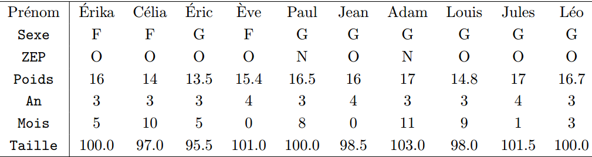

- *Exercice 2*

Create the following vectors

vec1 = 1 2 3 4 5 1 2 3 4 5 1 2 3 4 5

vec2 = 1 1 1 2 2 2 3 3 3 4 4 4 5 5 5

vec3 = 1 1 2 2 2 3 3 3 3 4 4 4 4 4